# Introducción a las anotaciones funcionales

Pablo Fonseca

12-07-2024

# Paquetes a instalar

Antes de comenzar, los siguientes paquetes deben ser instalados:

**biomaRt**

**ggplot2**

**patchwork**

**ggrepel**

**tidyverse**

**gprofiler2**

Todos los paquetes mencionados pueden encontrarse en los repositorios CRAN o Bioconductor. El código para instalar y cargar cada uno de estos paquetes se muestra antes de su uso en el presente tutorial.

# GO terms

## Paquete: biomaRt

El paquete biomaRt “proporciona una interfaz a una creciente colección de bases de datos que implementan la suite de software BioMart (http://www.biomart.org). El paquete permite la recuperación de grandes cantidades de datos de manera uniforme sin necesidad de conocer los esquemas de las bases de datos subyacentes o escribir consultas SQL complejas”. Por lo tanto toda la información disponible en la versión en línea de de Biomart, utilizando R.

Aquí, utilizaremos el mismo archivo de entrada utilizado en la versión en línea de Biomart.

```r
#El siguiente comando se puede utilizar para instalar el paquete
#(sólo es necesario eliminar el carácter de comentario #)
#BiocManager::install("biomaRt")

#Carga de los archivos de entrada
deg.list<-read.table("~/post_doc_Leon/Classes/summer_course_RNA_2023/Functional_annotation/DEG_Vega_2017.txt", h=T, sep="\t")

#Comprobar el archivo importado
head(deg.list)
```

|  | Gene | BaseMean | log2FC | pval | FDR |
| --- | --- | --- | --- | --- | --- |
| 1 | PON3 | 185.2096 | 1.7536 | 1.58e-11 | 1.89e-07 |
| 2 | LPIN1 | 1093.2689 | -1.7759 | 3.79e-10 | 2.26e-06 |
| 3 | ANGPTL4 | 708.1334 | 1.4698 | 2.63e-09 | 1.05e-05 |
| 4 | ENSOARG00000009821 | 17.8750 | 1.8552 | 1.17e-08 | 3.48e-05 |
| 5 | CYR61 | 1083.3347 | 1.6414 | 2.66e-08 | 6.35e-05 |
| 6 | SERTM1 | 32.7592 | -1.7838 | 3.69e-08 | 7.34e-05 |

```r
#Cargar el paquete
library(biomaRt)
```

Tras cargar el archivo de entrada y cargar el paquete, es posible iniciar la búsqueda de genes dentro de nuestro intervalo seleccionado.

1. El primer paso es elegir la base de datos y el organismo para elegir los genes

```r
#El siguiente comando muestra las bases de datos que están disponibles para recuperar información
#listMarts()

#Elegiremos ENSEMBL_MART_ENSEMBL, que corresponde a Ensembl Genes 91
#Es necesario crear un objeto del tipo "mart" para cargar la información de la base de datos.

#Esto se realiza con el siguiente comando:
mart <- useMart("ENSEMBL_MART_ENSEMBL")

#Una vez creado el objeto mart mediante la función useMart(), necesitamos seleccionar
#el organismo. El siguiente comando se puede utilizar para identificar el correspondiente
#argumento a cada organismo.

#listDatasets(mart)

#La función useDataset() puede utilizarse para insertar el organismo
#información en el objeto mart.
mart <- useDataset("hsapiens_gene_ensembl", mart)
```

2. Ahora es el momento de definir los filtros y atributos que se recuperarán de la base de datos.

```r
#Definir el filtro que se utilizará para recuperar la información
filter<-"external_gene_name"

#Crear un vector con los DEG
value<-deg.list$Gene

#Definir la información a recuperar de la base de datos
attributes <- c("external_gene_name","go_id","name_1006",
                "go_linkage_type", "namespace_1003")
```

3. Ahora, tras definir los filtros y los atributos, es el momento de recuperar la información

```r
#En este punto, necesitamos informar los objetos creados en los pasos anteriores como argumentos
#de la función getBM()

#Puede que necesites bajar la versión de dbplyr:
#devtools::install_version("dbplyr", version = "2.3.4")

all.genes <- getBM(attributes=attributes, filters=filter, values=value, mart=mart)

#Eliminación de genes sin anotación
all.genes<-all.genes[-which(all.genes$namespace_1003==""),]

#Comprobar la salidastr(all.genes)
head(all.genes)
```

|  | external_gene_name | go_id | name_1006 | go_linkage_type | namespace_1003 |
| --- | --- | --- | --- | --- | --- |
| 1 | CLDN8 | GO:0016020 | membrane | IEA | cellular_component |
| 2 | CLDN8 | GO:0005198 | structural molecule activity | IEA | molecular_function |
| 3 | CLDN8 | GO:0005923 | bicellular tight junction | IEA | cellular_component |
| 4 | CLDN8 | GO:0005783 | endoplasmic reticulum | HDA | cellular_component |
| 5 | CLDN8 | GO:0005515 | protein binding | IPI | molecular_function |
| 6 | CLDN8 | GO:0005886 | plasma membrane | IEA | cellular_component |

```r
#Guardar la salida
write.table(all.genes, file="output_biomart_DEG.txt",
            row.names=F, sep="\t", quote=F)
```

Utilizando el comando indicado anteriormente, es posible obtener los mismos resultados obtenidos en la versión en línea de biomart. Observe que es posible ejecutar estos comandos para todos los organismos disponibles en la base de datos Ensembl, para todos los

los filtros y atributos. Consulte el material de ayuda de cada función para obtener más información. Por ejemplo “?getBM()”.

El manual de biomaRt puede encontrarse aquí:

> https://bioconductor.org/packages/release/bioc/manuals/biomaRt/man/biomaRt.pdf

Ahora, vamos a comprobar los resultados y a crear algunos gráficos para resumir la información.

En primer lugar, podemos comprobar la distribución de los términos GO en las tres categorías: BP, MF y CC.

```r
#El primer paso es crear una tabla con el número de registros por categoría

go.table<-as.data.frame(table(all.genes$namespace_1003))

go.table$value<-round(go.table$Freq/sum(go.table$Freq),4)*100

head(go.table)
```

|  | Var1 | Freq | value |
| --- | --- | --- | --- |
| 1 | biological_process | 2556 | 45.70 |
| 2 | cellular_component | 1642 | 29.36 |
| 3 | molecular_function | 1395 | 24.94 |

Ahora, podemos trazar estos resultados como un gráfico circular utilizando ggplot2.

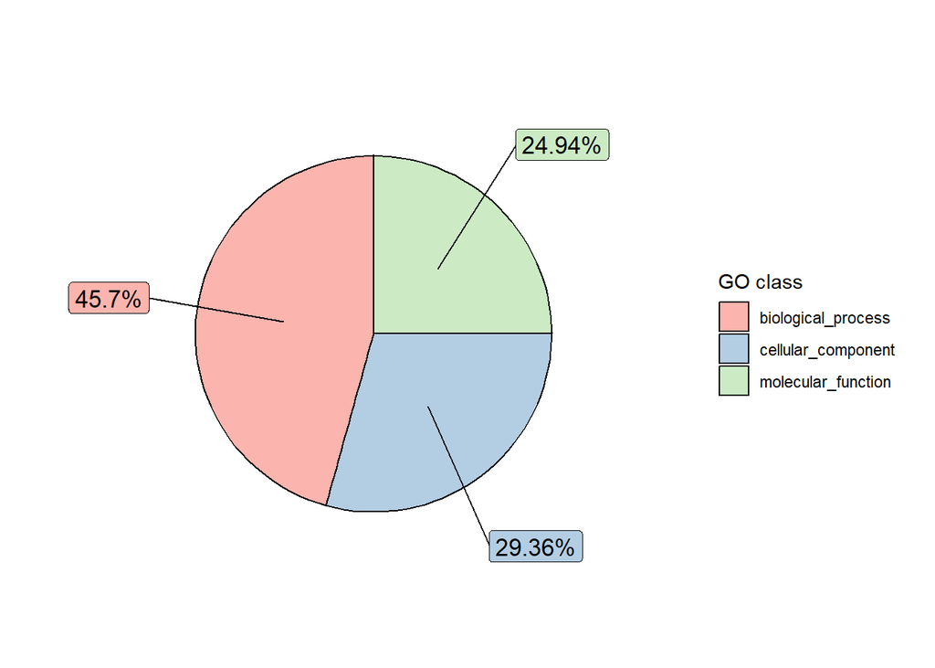

```r
library(ggplot2)
library(ggrepel)
library(tidyverse)
# Get the positions
go.table <- go.table %>%
  mutate(csum = rev(cumsum(rev(value))),
         pos = value/2 + lead(csum, 1))

go.table$pos<-if_else(is.na(go.table$pos), go.table$value/2, go.table$pos)

ggplot(go.table, aes(x = "" , y = value, fill = fct_inorder(Var1))) +
  geom_col(width = 1, color = 1) +
  coord_polar(theta = "y") +
  scale_fill_brewer(palette = "Pastel1") +
  geom_label_repel(data = go.table,
                   aes(y = pos, label = paste0(value, "%")),
                   size = 4.5, nudge_x = 1, show.legend = FALSE) +
  guides(fill = guide_legend(title = "GO class")) +
  theme_void()
```

Ahora podemos comprobar los diez términos más frecuentes dentro de cada clase GO y representarlos gráficamente.

```r
#Filtering the results table for BP and ordering from the most to the less frequent term
go.bp<-as.data.frame(table(all.genes[which(all.genes$namespace_1003=="biological_process"),
                       "go_id"]))

go.bp<-go.bp[order(go.bp$Freq, decreasing = T),]

go.bp$Var1<-factor(go.bp$Var1, levels = go.bp$Var1)

head(go.bp)
```

|  | Var1 | Freq |
| --- | --- | --- |
| 155 | GO:0006629 | 30 |
| 826 | GO:0045944 | 30 |
| 133 | GO:0006357 | 29 |
| 236 | GO:0007165 | 21 |
| 232 | GO:0007155 | 20 |
| 206 | GO:0006915 | 18 |

```r
#Filtering the results table for MF and ordering from the most to the less frequent term
go.mf<-as.data.frame(table(all.genes[which(all.genes$namespace_1003=="molecular_function"),
                       "go_id"]))

go.mf<-go.mf[order(go.mf$Freq, decreasing = T),]

go.mf$Var1<-factor(go.mf$Var1, levels = go.mf$Var1)

head(go.mf)
```

|  | Var1 | Freq |
| --- | --- | --- |
| 134 | GO:0005515 | 168 |
| 312 | GO:0046872 | 44 |
| 290 | GO:0042802 | 29 |
| 2 | GO:0000166 | 25 |
| 9 | GO:0000981 | 25 |
| 138 | GO:0005524 | 23 |

```r
#Filtering the results table for CC and ordering from the most to the less frequent term
go.cc<-as.data.frame(table(all.genes[which(all.genes$namespace_1003=="cellular_component"),
                       "go_id"]))

go.cc<-go.cc[order(go.cc$Freq, decreasing = T),]

go.cc$Var1<-factor(go.cc$Var1, levels = go.cc$Var1)

head(go.cc)
```

|  | Var1 | Freq |
| --- | --- | --- |
| 73 | GO:0005886 | 136 |
| 37 | GO:0005737 | 132 |
| 100 | GO:0016020 | 125 |
| 27 | GO:0005634 | 111 |
| 67 | GO:0005829 | 103 |
| 32 | GO:0005654 | 49 |

**BP**

```r
library(patchwork)
```

```r
bar.bp<-ggplot(go.bp[1:10,], aes(x = Var1 , y = Freq, fill=Freq)) +
  geom_bar(stat = "identity", ) +
  scale_fill_gradient(low = "lightblue", high = "darkblue") +
  theme_minimal() + ggtitle("Biological Process") +
  theme(axis.text.x = element_text(angle = 45, hjust = 1)) +
  xlab("GO term") + ylab("Number of genes")
```

**MF**

```r
bar.mf<-ggplot(go.mf[1:10,], aes(x = Var1 , y = Freq, fill = Freq)) +
  geom_bar(stat = "identity") +
  scale_fill_gradient(low = "lightblue", high = "darkblue") +
  theme_minimal() + ggtitle("Molecular Function") +
  theme(axis.text.x = element_text(angle = 45, hjust = 1)) +
  xlab("GO term") + ylab("Number of genes")
```

**CC**

```r
bar.cc<-ggplot(go.cc[1:10,], aes(x = Var1 , y = Freq, fill = Freq)) +
  geom_bar(stat = "identity") +
  scale_fill_gradient(low = "lightblue", high = "darkblue") +
  theme_minimal() + ggtitle("Cellular Component") +
  theme(axis.text.x = element_text(angle = 45, hjust = 1)) +
  xlab("GO term") + ylab("Number of genes")
```

Trazar los tres graficos con patchwork:

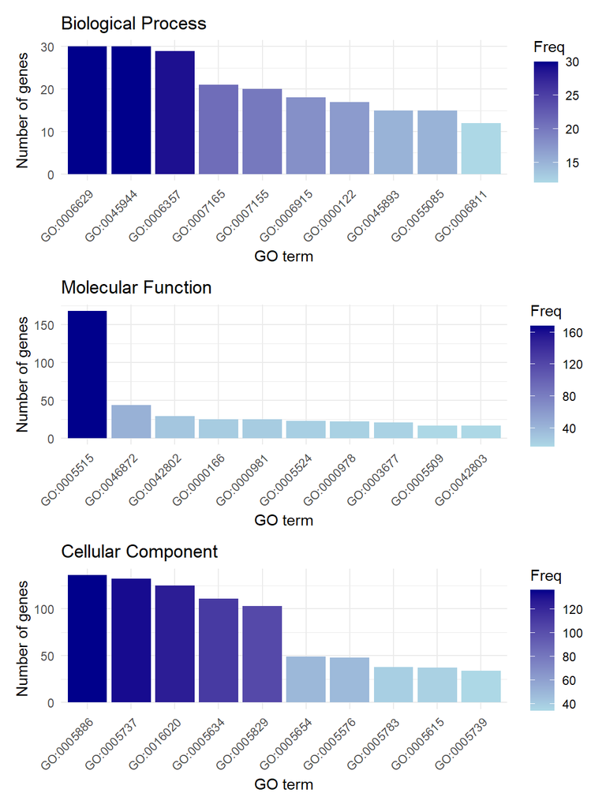

```r
bar.bp / bar.mf / bar.cc
```

# Rutas metabólicas

## Paquete gprofiler2

Del mismo modo, podemos realizar el mismo análisis para las rutas metabólicas. En este caso, utilizaremos el paquete *gprofiler2* para realizar la anotación utilizando vías KEGG y Reactome.

El paquete gprofiler2 es un conjunto de herramientas para el análisis y la visualización del enriquecimiento funcional, la conversión de identificadores gen/proteína/SNP y el mapeo de genes ortólogos entre especies a través de ‘g:Profiler’.

```r
library(gprofiler2)
#Anotación de vías KEGG y Reactome mediante Gene symbols
res.anno <- gost(query = deg.list$Gene,
                   organism = "hsapiens", exclude_iea = FALSE,
                   measure_underrepresentation = FALSE, evcodes = TRUE,
                   user_threshold = 1, correction_method = "fdr",
                   domain_scope = "annotated",
                   numeric_ns = "", sources = c("KEGG", "REAC"))

#Filtrar la tabla de resultados
res.anno<-res.anno$result

head(res.anno)
```

|  | query | significant | p_value | term_size | query_size | intersection_size | precision | recall | term_id | source | term_name | effective_domain_size | source_order | parents | evidence_codes | intersection |
| --- | --- | --- | --- | --- | --- | --- | --- | --- | --- | --- | --- | --- | --- | --- | --- | --- |
| 1 | query_1 | TRUE | 0.005422105 | 32 | 95 | 5 | 0.05263158 | 0.15625000 | KEGG:00640 | KEGG | Propanoate metabolism | 8484 | 109 |  | KEGG,KEGG,KEGG,KEGG,KEGG | ACSS2,ACACA,ACSS3,ACSS1,SUCLA2 |
| 2 | query_1 | TRUE | 0.045206927 | 57 | 95 | 5 | 0.05263158 | 0.08771930 | KEGG:01212 | KEGG | Fatty acid metabolism | 8484 | 186 |  | KEGG,KEGG,KEGG,KEGG,KEGG | FADS2,ACACA,ACSL1,PPT1,ELOVL6 |
| 3 | query_1 | TRUE | 0.054919577 | 135 | 95 | 7 | 0.07368421 | 0.05185185 | KEGG:04210 | KEGG | Apoptosis | 8484 | 287 |  | KEGG,KEGG,KEGG,KEGG,KEGG,KEGG,KEGG | CTSF,ATF4,JUN,CSF2RB,MCL1,GADD45G,CTSK |
| 4 | query_1 | TRUE | 0.056183806 | 22 | 95 | 3 | 0.03157895 | 0.13636364 | KEGG:00900 | KEGG | Terpenoid backbone biosynthesis | 8484 | 129 |  | KEGG,KEGG,KEGG | MVD,HMGCS1,FDPS |
| 5 | query_1 | TRUE | 0.056183806 | 47 | 95 | 4 | 0.04210526 | 0.08510638 | KEGG:00620 | KEGG | Pyruvate metabolism | 8484 | 99 |  | KEGG,KEGG,KEGG,KEGG | ACSS2,ACACA,PCK2,ACSS1 |
| 6 | query_1 | TRUE | 0.056183806 | 75 | 95 | 5 | 0.05263158 | 0.06666667 | KEGG:03320 | KEGG | PPAR signaling pathway | 8484 | 236 |  | KEGG,KEGG,KEGG,KEGG,KEGG | ANGPTL4,FADS2,ACSL1,HMGCS1,PCK2 |

Ahora, podemos filtrar los resultados de cada base de datos y comparar los resultados.

```r
#Filtrado de resultados de KEGG
res.kegg<-res.anno[which(res.anno$source=="KEGG"),]
res.kegg<-res.kegg[order(res.kegg$intersection_size, decreasing = T),]
res.kegg$term_id<-factor(res.kegg$term_id, levels=res.kegg$term_id)

#Filtrado de resultados de Reactome
res.reac<-res.anno[which(res.anno$source=="REAC"),]
res.reac<-res.reac[order(res.reac$intersection_size, decreasing = T),]
res.reac$term_id<-factor(res.reac$term_id, levels=res.reac$term_id)
```

**KEGG**

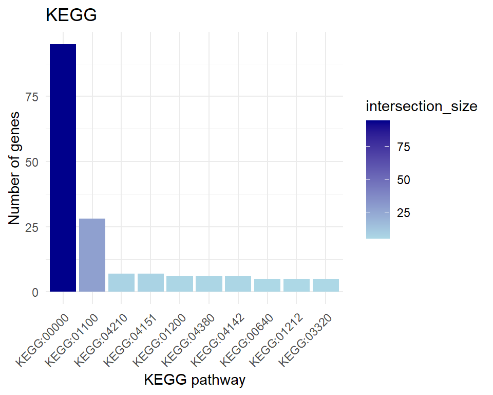

```r
ggplot(res.kegg[1:10,], aes(x = term_id , y = intersection_size,
                                      fill = intersection_size)) +
  geom_bar(stat = "identity") +
  scale_fill_gradient(low = "lightblue", high = "darkblue") +
  theme_minimal() + ggtitle("KEGG") +
  theme(axis.text.x = element_text(angle = 45, hjust = 1)) +
  xlab("KEGG pathway") + ylab("Number of genes")
```

```r
res.kegg[1:10,c("term_id","term_name")]
```

|  | term_id | term_name |
| --- | --- | --- |
| 216 | KEGG:00000 | KEGG root term |
| 10 | KEGG:01100 | Metabolic pathways |
| 3 | KEGG:04210 | Apoptosis |
| 40 | KEGG:04151 | PI3K-Akt signaling pathway |
| 7 | KEGG:01200 | Carbon metabolism |
| 8 | KEGG:04380 | Osteoclast differentiation |
| 9 | KEGG:04142 | Lysosome |
| 1 | KEGG:00640 | Propanoate metabolism |
| 2 | KEGG:01212 | Fatty acid metabolism |
| 6 | KEGG:03320 | PPAR signaling pathway |

**Reactome**

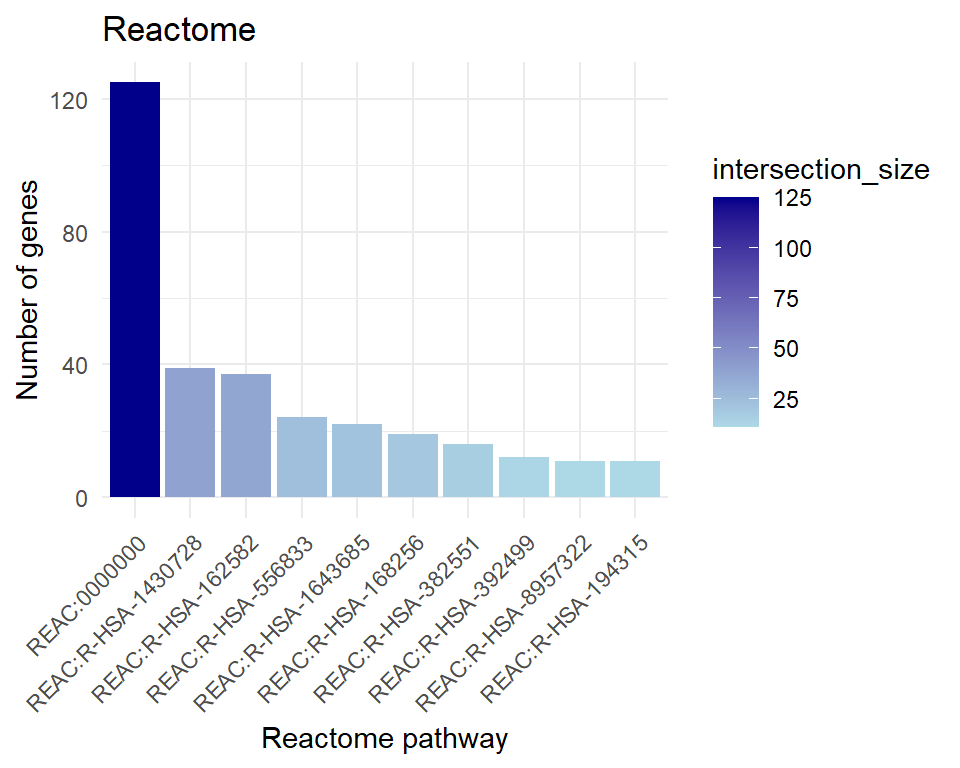

```r
ggplot(res.reac[1:10,], aes(x = term_id , y = intersection_size,
                                      fill = intersection_size)) +
  geom_bar(stat = "identity") +
  scale_fill_gradient(low = "lightblue", high = "darkblue") +
  theme_minimal() + ggtitle("Reactome") +
  theme(axis.text.x = element_text(angle = 45, hjust = 1)) +
  xlab("Reactome pathway") + ylab("Number of genes")
```

```r
res.reac[1:10,c("term_id","term_name")]
```

|  | term_id | term_name |
| --- | --- | --- |
| 838 | REAC:0000000 | REACTOME root term |
| 223 | REAC:R-HSA-1430728 | Metabolism |
| 308 | REAC:R-HSA-162582 | Signal Transduction |
| 217 | REAC:R-HSA-556833 | Metabolism of lipids |
| 581 | REAC:R-HSA-1643685 | Disease |
| 806 | REAC:R-HSA-168256 | Immune System |
| 246 | REAC:R-HSA-382551 | Transport of small molecules |
| 837 | REAC:R-HSA-392499 | Metabolism of proteins |
| 218 | REAC:R-HSA-8957322 | Metabolism of steroids |
| 417 | REAC:R-HSA-194315 | Signaling by Rho GTPases |

Presta atención al término más frecuente. ¿Tiene sentido? ¿Cómo debemos interpretar estos resultados?

Los términos muy amplios y no relacionados con nuestros fenotipos (al menos en un primer momento) deben interpretarse con cuidado.